# Dkk1 RNA-seq analysis

Félix Distéfano-Gagné

2023-06-19

# Data

Dataset prepared by David Gosselin (cmd=analyzeRepeats.pl rna mm10 -pc 3 -count exons -condenseGenes -raw -d WI1flip/ WI2flip/ WI3flip/ WC1flip/ WC2flip/ WC3flip/ DI1flip/ DI2flip DI3flip/ DC1flip/ DC2flip/ DC3flip/). For TPM set, replaced -raw by -tpm.

```r
Raw <- read_tsv('ElAli_RNA_raw_220623.txt')
colnames(Raw)[c(1, 8:20)] <- c('TranscriptID', 'Annotation', 'WI_1', 'WI_2',
                               'WI_3', 'WC_1', 'WC_2', 'WC_3', 'DI_1', 'DI_2',
                               'DI_3', 'DC_1', 'DC_2', 'DC_3')
Raw <- Raw %>%
  mutate(Gene = str_remove(Annotation, '\\|.*'))
head(Raw)
```

```
## # A tibble: 6 × 21
##   TranscriptID chr      start    end strand Length Copies Annotation  WI_1  WI_2
##   <chr>        <chr>    <dbl>  <dbl> <chr>   <dbl>  <dbl> <chr>      <dbl> <dbl>
## 1 NM_172405    chr5    1.01e8 1.01e8 -        2488      1 Abraxas1|…   237   153
## 2 NM_001359283 chr10   4.28e7 4.28e7 +        6006      1 Sec63|573…  3110  2923
## 3 NM_001168290 chr8    7.02e7 7.03e7 +        4089      1 Sugp2|Sfr…  2716  2605
## 4 NM_178061    chr4    3.49e7 3.52e7 -        6024      1 Mob3b|843…   641   269
## 5 NR_029557    chr18   6.16e7 6.16e7 -          69      1 Mir145a|M…     3     0
## 6 NR_045798    chr13   6.42e7 6.43e7 +        1799      1 1810034E1…    46    31
## # ℹ 11 more variables: WI_3 <dbl>, WC_1 <dbl>, WC_2 <dbl>, WC_3 <dbl>,
## #   DI_1 <dbl>, DI_2 <dbl>, DI_3 <dbl>, DC_1 <dbl>, DC_2 <dbl>, DC_3 <dbl>,
## #   Gene <chr>
```

```r
Tpm <- read_tsv('Elali_RNA_TPM_230110.txt')
colnames(Tpm)[c(1, 8:20)] <- c('TranscriptID', 'Annotation', 'WI_1', 'WI_2',
                               'WI_3', 'WC_1', 'WC_2', 'WC_3', 'DI_1', 'DI_2',
                               'DI_3', 'DC_1', 'DC_2', 'DC_3')
Tpm <- Tpm %>%
  mutate(Gene = str_remove(Annotation, '\\|.*'))
head(Tpm)
```

```
## # A tibble: 6 × 21
##   TranscriptID chr    start    end strand Length Copies Annotation   WI_1   WI_2
##   <chr>        <chr>  <dbl>  <dbl> <chr>   <dbl>  <dbl> <chr>       <dbl>  <dbl>
## 1 NM_001159385 chr11 1.01e8 1.01e8 +        1803      1 Mlx|Tcfl4… 20.7   22.5
## 2 NM_008017    chr4  5.24e7 5.25e7 +        5428      1 Smc2|5730…  3.34   3.82
## 3 NM_026756    chr10 8.14e7 8.14e7 -        6207      1 Nfic|1110… 53.2   44.9
## 4 NM_001357955 chr11 6.26e7 6.26e7 -        1704      1 Lrrc75a|F… 13.5   11.5
## 5 NM_177330    chr3  2.74e7 2.74e7 +        4428      1 Ghsr|C530…  0.165  0.066
## 6 NR_106077    chr17 2.74e7 2.74e7 +          58      1 Mir7218|m…  0      0
## # ℹ 11 more variables: WI_3 <dbl>, WC_1 <dbl>, WC_2 <dbl>, WC_3 <dbl>,
## #   DI_1 <dbl>, DI_2 <dbl>, DI_3 <dbl>, DC_1 <dbl>, DC_2 <dbl>, DC_3 <dbl>,
## #   Gene <chr>
```

# Annotation

Mandatory step for DESeq2 object preparation.

```r
Row <- data.frame(Raw[, 21])
GeneID <- substr(Row[, 1], 1, 17)
Row$Symbol <- mapIds(org.Mm.eg.db,
                     keys = GeneID,
                     column = 'SYMBOL',
                     keytype = 'SYMBOL')
Row$Entrez <- mapIds(org.Mm.eg.db,
                     keys = GeneID,
                     column = 'ENTREZID',
                     keytype = 'SYMBOL',
                     multiVals = 'first')
```

# Arranging DESeq2 object

We have two variables of interest here: side (contra vs ipsi) and genotype (KO vs WT). We’ll want four main comparisons: IpsiKO vs IpsiWT, ContraKO vs ContraWT, ContraWT vs IpsiWT and ContraKO vs IpsiKO. The design matrix will be done to reflect this.

```r
Set <- data.frame(Raw, row.names = 21)
Set_Mat <- as.matrix(Set[, 9:20])
ColData <- data.frame(Samples = 1:12,
                      ID = c('WI_1', 'WI_2', 'WI_3', 'WC_1', 'WC_2', 'WC_3',
                             'DI_1', 'DI_2', 'DI_3', 'DC_1', 'DC_2', 'DC_3'),
                      Genotype = factor(c(rep('WT', 6),
                                          rep('KO', 6)),
                                        levels = c('WT', 'KO')),
                      Side = factor(c(rep('Ipsilateral', 3),
                                      rep('Contralateral', 3),
                                      rep('Ipsilateral', 3),
                                      rep('Contralateral', 3)),
                                    levels = c('Contralateral', 'Ipsilateral')),
                      Replicate = c(1, 2, 3, 1, 2, 3, 1, 2, 3, 1, 2, 3)) %>%
  column_to_rownames(var = 'ID')
all(rownames(ColData) == colnames(Set_Mat))
```

```
## [1] TRUE
```

```r
ColData$Group <- factor(paste0(ColData$Side, ColData$Genotype),
                        levels = c('ContralateralWT', 'IpsilateralWT',
                                   'ContralateralKO', 'IpsilateralKO'))
ColData
```

```
##      Samples Genotype          Side Replicate           Group
## WI_1       1       WT   Ipsilateral         1   IpsilateralWT
## WI_2       2       WT   Ipsilateral         2   IpsilateralWT
## WI_3       3       WT   Ipsilateral         3   IpsilateralWT
## WC_1       4       WT Contralateral         1 ContralateralWT
## WC_2       5       WT Contralateral         2 ContralateralWT
## WC_3       6       WT Contralateral         3 ContralateralWT
## DI_1       7       KO   Ipsilateral         1   IpsilateralKO
## DI_2       8       KO   Ipsilateral         2   IpsilateralKO
## DI_3       9       KO   Ipsilateral         3   IpsilateralKO
## DC_1      10       KO Contralateral         1 ContralateralKO
## DC_2      11       KO Contralateral         2 ContralateralKO
## DC_3      12       KO Contralateral         3 ContralateralKO
```

```r
DE_Set <- DESeqDataSetFromMatrix(countData = Set_Mat,
                                 colData = ColData,
                                 design = ~Group,
                                 rowData = Row)
DE_Set
```

```
## class: DESeqDataSet
## dim: 25124 12
## metadata(1): version
## assays(1): counts
## rownames(25124): Abraxas1 Sec63 ... Nrn1l Kcne1
## rowData names(3): Gene Symbol Entrez
## colnames(12): WI_1 WI_2 ... DC_2 DC_3
## colData names(5): Samples Genotype Side Replicate Group
```

# Applying DESeq2 model

We apply a Wald test to ID differentially expressed genes. We use a logFoldChange of 0 looking for a simple difference.

```r
DE_Set <- DESeq(DE_Set, test = 'Wald')
DE_Set
```

```
## class: DESeqDataSet
## dim: 25124 12
## metadata(1): version
## assays(4): counts mu H cooks
## rownames(25124): Abraxas1 Sec63 ... Nrn1l Kcne1
## rowData names(33): Gene Symbol ... deviance maxCooks
## colnames(12): WI_1 WI_2 ... DC_2 DC_3
## colData names(6): Samples Genotype ... Group sizeFactor
```

```r
sizeFactors(DE_Set) == estimateSizeFactorsForMatrix(Set_Mat)
```

```
## WI_1 WI_2 WI_3 WC_1 WC_2 WC_3 DI_1 DI_2 DI_3 DC_1 DC_2 DC_3
## TRUE TRUE TRUE TRUE TRUE TRUE TRUE TRUE TRUE TRUE TRUE TRUE
```

```r
sizeFactors(DE_Set)
```

```
##      WI_1      WI_2      WI_3      WC_1      WC_2      WC_3      DI_1      DI_2
## 1.0947007 1.0287887 1.0694256 1.0739760 0.9490633 0.9657697 1.0488819 0.9961238
##      DI_3      DC_1      DC_2      DC_3
## 1.1024436 0.8220039 0.9980267 0.9323493
```

```r
colSums(counts(DE_Set))
```

```
##     WI_1     WI_2     WI_3     WC_1     WC_2     WC_3     DI_1     DI_2
## 25744445 24922387 25550152 26911834 24056550 24083936 25435715 24242073
##     DI_3     DC_1     DC_2     DC_3
## 26011661 21209925 24336229 23558892
```

```r
colSums(counts(DE_Set, normalized=T))
```

```
##     WI_1     WI_2     WI_3     WC_1     WC_2     WC_3     DI_1     DI_2
## 23517337 24224982 23891473 25058134 25347676 24937555 24250313 24336405
##     DI_3     DC_1     DC_2     DC_3
## 23594549 25802707 24384347 25268312
```

```r
LFC <- 0
FDR <- 0.05
resultsNames(DE_Set)
```

```
## [1] "Intercept"
## [2] "Group_IpsilateralWT_vs_ContralateralWT"
## [3] "Group_ContralateralKO_vs_ContralateralWT"
## [4] "Group_IpsilateralKO_vs_ContralateralWT"
```

```r
cont_WI_WC <- c('Group', 'IpsilateralWT', 'ContralateralWT')
cont_DC_WC <- c('Group', 'ContralateralKO', 'ContralateralWT')
cont_DI_WC <- c('Group', 'IpsilateralKO', 'ContralateralWT')
cont_DI_WI <- c('Group', 'IpsilateralKO', 'IpsilateralWT')
cont_DI_DC <- c('Group', 'IpsilateralKO', 'ContralateralKO')
```

# Getting results

We perform contrasts here.

```r
# IpsiWT vs ContraWT
res_WI_WC <- results(DE_Set, contrast = cont_WI_WC, alpha = FDR,
                     lfcThreshold = LFC)
res_WI_WC <- res_WI_WC %>%
  data.frame() %>%
  rownames_to_column(var = 'Gene') %>%
  as_tibble()
colnames(res_WI_WC)[c(3, 7)] <- c('WI_WC_log2FC',
                                  'WI_WC_padj')

# ContraKO vs ContraWT
res_DC_WC <- results(DE_Set, contrast = cont_DC_WC, alpha = FDR,
                     lfcThreshold = LFC)
res_DC_WC <- res_DC_WC %>%
  data.frame() %>%
  rownames_to_column(var = 'Gene') %>%
  as_tibble()
colnames(res_DC_WC)[c(3, 7)] <- c('DC_WC_log2FC',
                                  'DC_WC_padj')

# IpsiKO vs ContraWT
res_DI_WC <- results(DE_Set, contrast = cont_DI_WC, alpha = FDR,
                     lfcThreshold = LFC)
res_DI_WC <- res_DI_WC %>%
  data.frame() %>%
  rownames_to_column(var = 'Gene') %>%
  as_tibble()
colnames(res_DI_WC)[c(3, 7)] <- c('DI_WC_log2FC',
                                  'DI_WC_padj')

# Ipsi KO vs Ipsi WT
DE_Set$Group <- relevel(DE_Set$Group, ref = 'IpsilateralWT')
DE_Set <- nbinomWaldTest(DE_Set)
```

```
## found results columns, replacing these
```

```r
res_DI_WI <- results(DE_Set, contrast = cont_DI_WI, alpha = FDR,
                     lfcThreshold = LFC)
res_DI_WI <- res_DI_WI %>%
  data.frame() %>%
  rownames_to_column(var = 'Gene') %>%
  as_tibble()
colnames(res_DI_WI)[c(3, 7)] <- c('DI_WI_log2FC',
                                  'DI_WI_padj')

# Ipsi KO vs ContraKO
DE_Set$Group <- relevel(DE_Set$Group, ref = 'ContralateralKO')
DE_Set <- nbinomWaldTest(DE_Set)
```

```
## found results columns, replacing these
```

```r
res_DI_DC <- results(DE_Set, contrast = cont_DI_DC, alpha = FDR,
                     lfcThreshold = LFC)
res_DI_DC <- res_DI_DC %>%
  data.frame() %>%
  rownames_to_column(var = 'Gene') %>%
  as_tibble()
colnames(res_DI_DC)[c(3, 7)] <- c('DI_DC_log2FC',
                                  'DI_DC_padj')
```

# Curating dataset for visualisation

Putting results back to TPM table and filtering to keep only protein-coding genes and ID DEGs.Note that the statistical tests were done on normalized raw count data, not TPM. We however prefer to use TPM for visualizations as it’s a more stable, recognized unit.

```r
Diff_set <- Tpm %>%
  inner_join(res_WI_WC[, c(1, 3, 7)]) %>%
  inner_join(res_DC_WC[, c(1, 3, 7)]) %>%
  inner_join(res_DI_WC[, c(1, 3, 7)]) %>%
  inner_join(res_DI_WI[, c(1, 3, 7)]) %>%
  inner_join(res_DI_DC[, c(1, 3, 7)]) %>%
  filter(str_detect(Annotation, 'protein-coding'))
Diff_set <- Diff_set %>%
  mutate(WI_WC_Status = case_when(WI_WC_log2FC > LFC &
                                    WI_WC_padj < FDR ~ 'WI',
                                  WI_WC_log2FC < -LFC &
                                    WI_WC_padj < FDR ~ 'WC',
                                  TRUE ~ 'Not'),
         DC_WC_Status = case_when(DC_WC_log2FC > LFC &
                                    DC_WC_padj < FDR ~ 'DC',
                                  DC_WC_log2FC < -LFC &
                                    DC_WC_padj < FDR ~ 'WC',
                                  TRUE ~ 'Not'),
         DI_WC_Status = case_when(DI_WC_log2FC > LFC &
                                    DI_WC_padj < FDR ~ 'DI',
                                  DI_WC_log2FC < -LFC &
                                    DI_WC_padj < FDR ~ 'WC',
                                  TRUE ~ 'Not'),
         DI_WI_Status = case_when(DI_WI_log2FC > LFC &
                                    DI_WI_padj < FDR ~ 'DI',
                                  DI_WI_log2FC < -LFC &
                                    DI_WI_padj < FDR ~ 'WI',
                                  TRUE ~ 'Not'),
         DI_DC_Status = case_when(DI_DC_log2FC > LFC &
                                    DI_DC_padj < FDR ~ 'DI',
                                  DI_DC_log2FC < -LFC &
                                    DI_DC_padj < FDR ~ 'DC',
                                  TRUE ~ 'Not'))
```

# Volcano plots

Labeled and unlabeled versions of the plots are provided. The labeled version will accurately pinpoint the genes, but positions of the labels are generated automatically and are difficult to control. The unlabeled version can serve to manually add lines and labels in Illustrator/Inkscape as in the provided plot, but with more convenient positions.

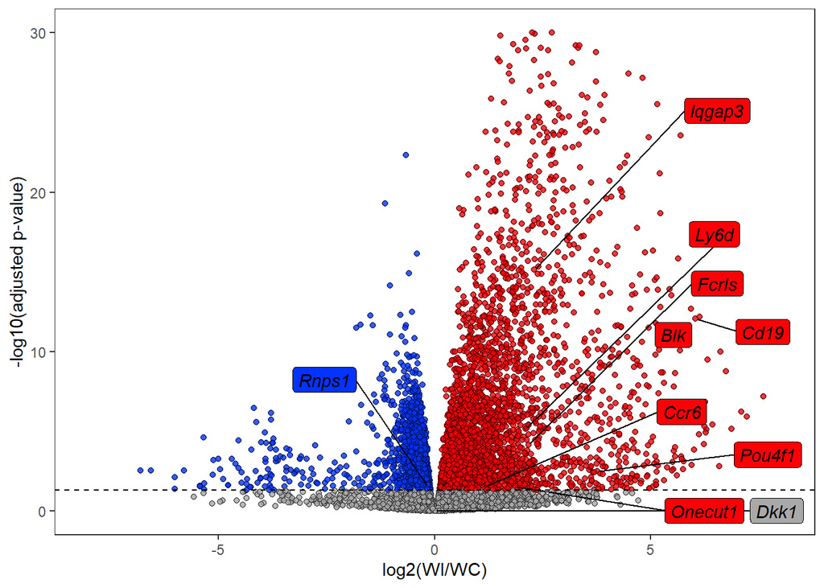

```r
# Labelled genes
Labelled <- c('Dkk1', 'Cd19', 'Ly6d', 'Blk', 'Aspg',
              'Onecut1', 'Rnps1', 'Pou4f1', 'Fcrls', 'Iqgap3', 'Ccr6')
Diff_set <- Diff_set %>%
  mutate(Labels = ifelse(Gene %in% Labelled,
                         Gene,
                         ''))

# WI vs WC
Diff_set %>%
  ggplot(aes(WI_WC_log2FC, -log10(WI_WC_padj), fill = WI_WC_Status,
             label = Labels)) +
  geom_point(shape = 21, color = 'black', alpha = 0.8) +
  geom_hline(yintercept = -log10(FDR), linetype = 2) +
  xlab('log2(WI/WC)') +
  ylab('-log10(adjusted p-value)') +
  scale_y_continuous(limits = c(0, 30)) +
  scale_x_continuous(limits = c(-8, 8)) +
  scale_fill_manual(values = c('#a9a9a9',
                                        rgb(4, 51, 255, maxColorValue = 255),
                                        rgb(251, 1, 6, maxColorValue = 255))) +
  geom_label_repel(box.padding = 0.5,
                   force = 10,
                   max.overlaps = Inf,
                   fontface = 'italic') +
  theme_bw() +
  theme(legend.position = 'none',
        panel.grid = element_blank())
```

```r
ggsave('230619_ElAli_Volcano_WIvsWC.pdf', width = 4, height = 4, units = 'in')
```

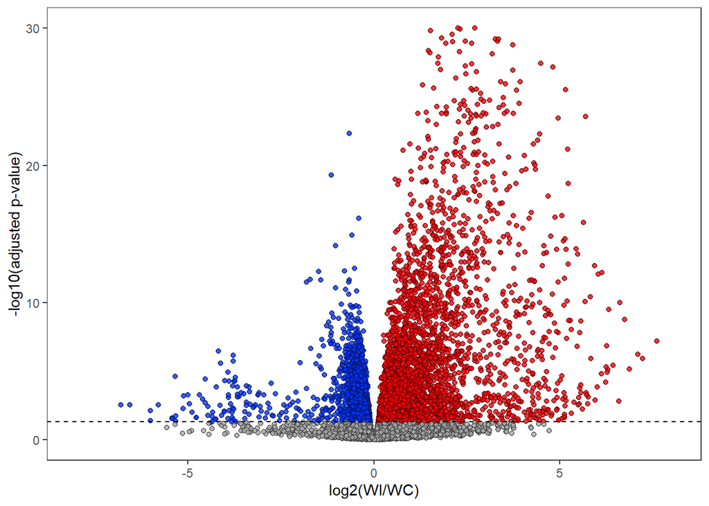

```r
Diff_set %>%
  ggplot(aes(WI_WC_log2FC, -log10(WI_WC_padj), fill = WI_WC_Status,
             label = Labels)) +
  geom_point(shape = 21, color = 'black', alpha = 0.8) +
  geom_hline(yintercept = -log10(FDR), linetype = 2) +
  xlab('log2(WI/WC)') +
  ylab('-log10(adjusted p-value)') +
  scale_y_continuous(limits = c(0, 30)) +
  scale_x_continuous(limits = c(-8, 8)) +
  scale_fill_manual(values = c('#a9a9a9',
                                        rgb(4, 51, 255, maxColorValue = 255),
                                        rgb(251, 1, 6, maxColorValue = 255))) +
  theme_bw() +
  theme(legend.position = 'none',
        panel.grid = element_blank())
```

```r
ggsave('230619_ElAli_Volcano_WIvsWC_unlabeled.pdf',
       width = 4, height = 4, units = 'in')
```

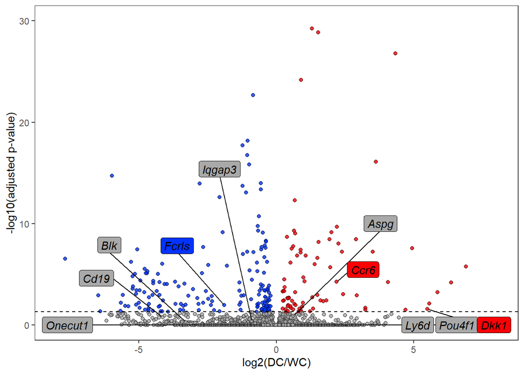

```r
# DC vs WC
Diff_set %>%
  ggplot(aes(DC_WC_log2FC, -log10(DC_WC_padj), fill = DC_WC_Status,
             label = Labels)) +
  geom_point(shape = 21, color = 'black', alpha = 0.8) +
  geom_hline(yintercept = -log10(FDR), linetype = 2) +
  xlab('log2(DC/WC)') +
  ylab('-log10(adjusted p-value)') +
  scale_y_continuous(limits = c(0, 30)) +
  scale_x_continuous(limits = c(-8, 8)) +
  scale_fill_manual(values = c(rgb(251, 1, 6, maxColorValue = 255),
                               '#a9a9a9',
                               rgb(4, 51, 255, maxColorValue = 255))) +
  geom_label_repel(box.padding = 0.5,
                   force = 55,
                   max.overlaps = Inf,
                   fontface = 'italic') +
  theme_bw() +
  theme(legend.position = 'none',
        panel.grid = element_blank())
```

```r
ggsave('230619_ElAli_Volcano_DCvsWC.pdf', width = 4, height = 4, units = 'in')
```

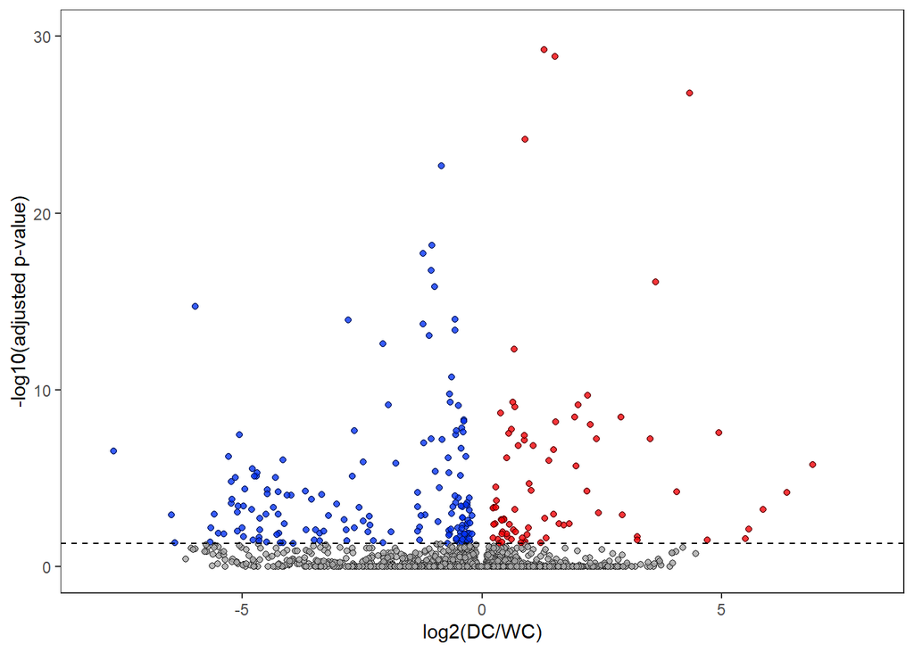

```r
Diff_set %>%
  ggplot(aes(DC_WC_log2FC, -log10(DC_WC_padj), fill = DC_WC_Status,
             label = Labels)) +
  geom_point(shape = 21, color = 'black', alpha = 0.8) +
  geom_hline(yintercept = -log10(FDR), linetype = 2) +
  xlab('log2(DC/WC)') +
  ylab('-log10(adjusted p-value)') +
  scale_y_continuous(limits = c(0, 30)) +
  scale_x_continuous(limits = c(-8, 8)) +
  scale_fill_manual(values = c(rgb(251, 1, 6, maxColorValue = 255),
                               '#a9a9a9',
                               rgb(4, 51, 255, maxColorValue = 255))) +
  theme_bw() +
  theme(legend.position = 'none',
        panel.grid = element_blank())
```

```r
ggsave('230619_ElAli_Volcano_DCvsWC_unlabeled.pdf',
       width = 4, height = 4, units = 'in')
```

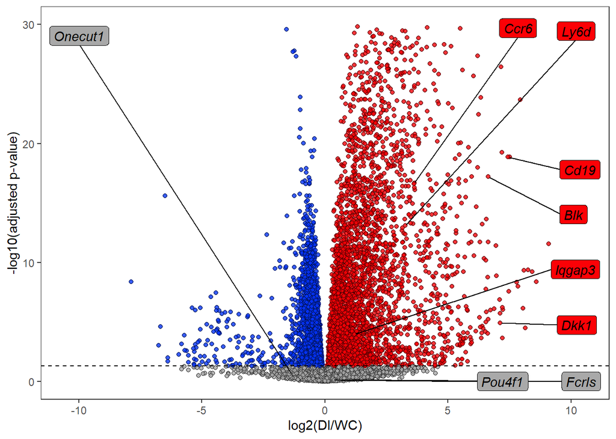

```r
# DC vs WI
Diff_set %>%
  ggplot(aes(DI_WC_log2FC, -log10(DI_WC_padj), fill = DI_WC_Status,
             label = Labels)) +
  geom_point(shape = 21, color = 'black', alpha = 0.8) +
  geom_hline(yintercept = -log10(FDR), linetype = 2) +
  xlab('log2(DI/WC)') +
  ylab('-log10(adjusted p-value)') +
  scale_y_continuous(limits = c(0, 30)) +
  scale_x_continuous(limits = c(-10.5, 10.5)) +
  scale_fill_manual(values = c(rgb(251, 1, 6, maxColorValue = 255),
                               '#a9a9a9',
                               rgb(4, 51, 255, maxColorValue = 255))) +
  geom_label_repel(box.padding = 0.5,
                   force = 200,
                   max.overlaps = Inf,
                   fontface = 'italic') +
  theme_bw() +
  theme(legend.position = 'none',
        panel.grid = element_blank())
```

```r
ggsave('230619_ElAli_Volcano_DIvsWC.pdf', width = 4, height = 4, units = 'in')
```

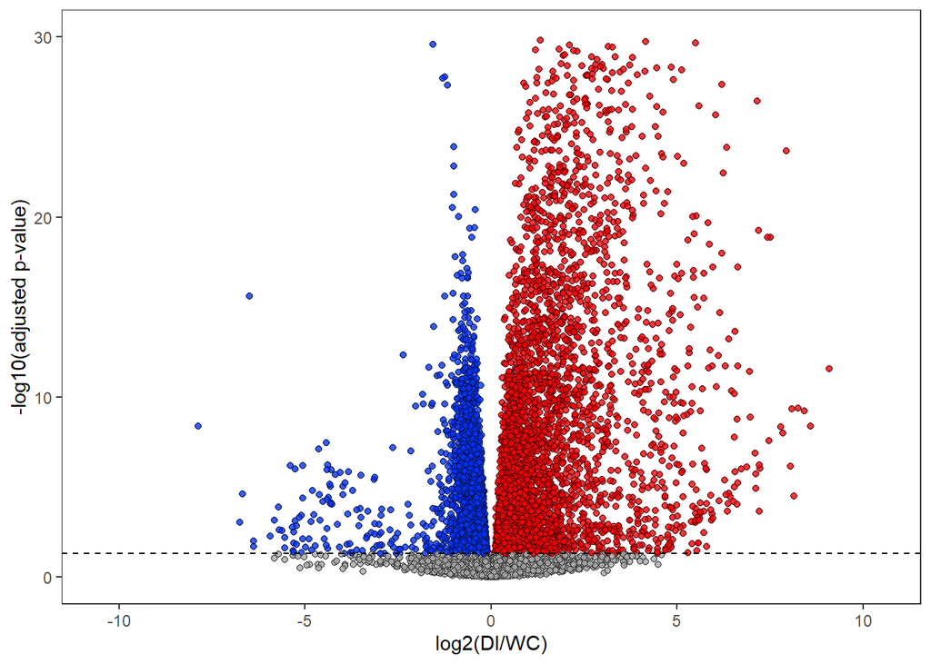

```r
Diff_set %>%
  ggplot(aes(DI_WC_log2FC, -log10(DI_WC_padj), fill = DI_WC_Status,
             label = Labels)) +
  geom_point(shape = 21, color = 'black', alpha = 0.8) +
  geom_hline(yintercept = -log10(FDR), linetype = 2) +
  xlab('log2(DI/WC)') +
  ylab('-log10(adjusted p-value)') +
    scale_y_continuous(limits = c(0, 30)) +
  scale_x_continuous(limits = c(-10.5, 10.5)) +
  scale_fill_manual(values = c(rgb(251, 1, 6, maxColorValue = 255),
                               '#a9a9a9',
                               rgb(4, 51, 255, maxColorValue = 255))) +
  theme_bw() +
  theme(legend.position = 'none',
        panel.grid = element_blank())
```

```r
ggsave('230619_ElAli_Volcano_DIvsWC_unlabeled.pdf',
       width = 4, height = 4, units = 'in')
```

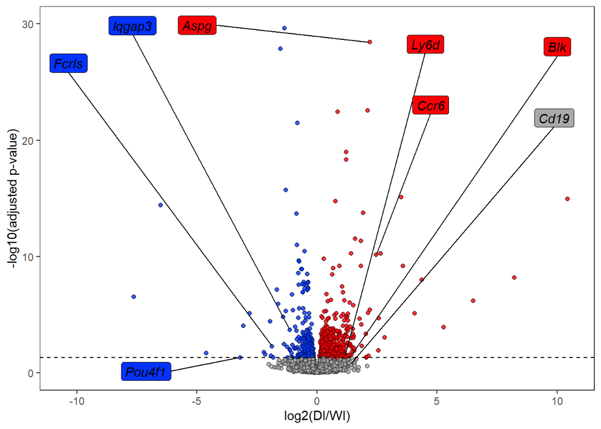

```r
# DI vs WI
Diff_set %>%
  ggplot(aes(DI_WI_log2FC, -log10(DI_WI_padj), fill = DI_WI_Status,
             label = Labels)) +
  geom_point(shape = 21, color = 'black', alpha = 0.8) +
  geom_hline(yintercept = -log10(FDR), linetype = 2) +
  xlab('log2(DI/WI)') +
  ylab('-log10(adjusted p-value)') +
    scale_y_continuous(limits = c(0, 30)) +
  scale_x_continuous(limits = c(-10.5, 10.5)) +
  scale_fill_manual(values = c(rgb(251, 1, 6, maxColorValue = 255),
                               '#a9a9a9',
                               rgb(4, 51, 255, maxColorValue = 255))) +
  geom_label_repel(box.padding = 0.5,
                   force = 200,
                   max.overlaps = Inf,
                   fontface = 'italic') +
  theme_bw() +
  theme(legend.position = 'none',
        panel.grid = element_blank())
```

```r
ggsave('230619_ElAli_Volcano_DIvsWI.pdf', width = 4, height = 4, units = 'in')
```

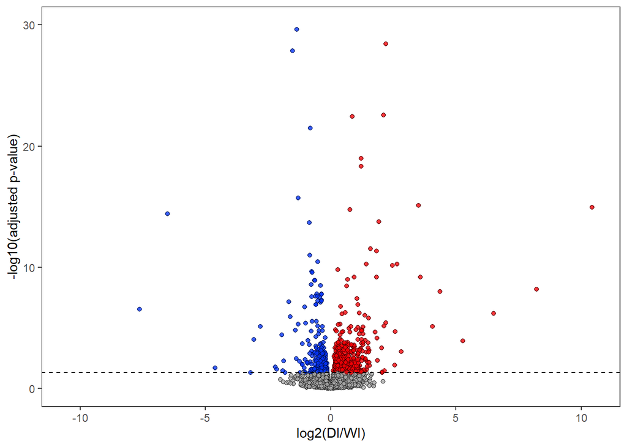

```r
Diff_set %>%
  ggplot(aes(DI_WI_log2FC, -log10(DI_WI_padj), fill = DI_WI_Status,
             label = Labels)) +
  geom_point(shape = 21, color = 'black', alpha = 0.8) +
  geom_hline(yintercept = -log10(FDR), linetype = 2) +
  xlab('log2(DI/WI)') +
  ylab('-log10(adjusted p-value)') +
    scale_y_continuous(limits = c(0, 30)) +
  scale_x_continuous(limits = c(-10.5, 10.5)) +
  scale_fill_manual(values = c(rgb(251, 1, 6, maxColorValue = 255),
                               '#a9a9a9',
                               rgb(4, 51, 255, maxColorValue = 255))) +
  theme_bw() +
  theme(legend.position = 'none',
        panel.grid = element_blank())
```

```r
ggsave('230619_ElAli_Volcano_DIvsWI_unlabeled.pdf',
       width = 4, height = 4, units = 'in')
```

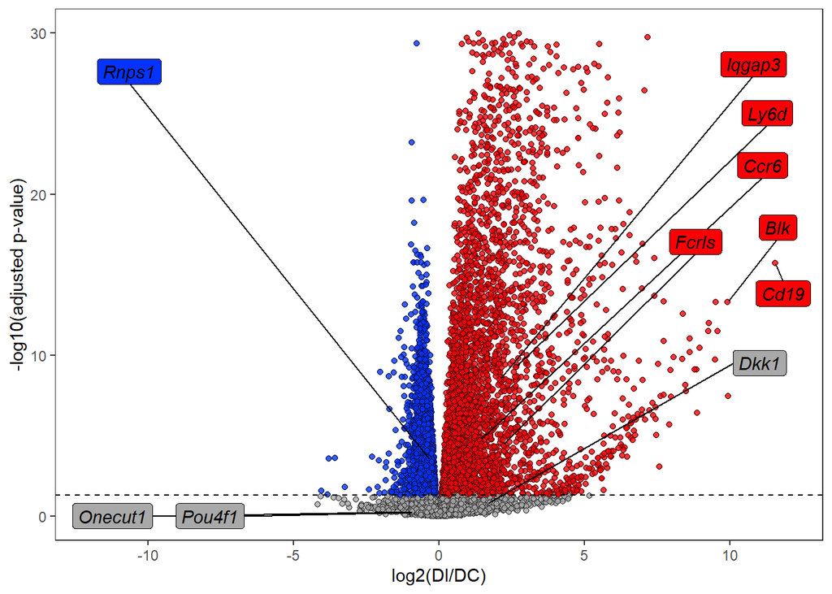

```r
# DI vs DC
Diff_set %>%
  ggplot(aes(DI_DC_log2FC, -log10(DI_DC_padj), fill = DI_DC_Status,
             label = Labels)) +
  geom_point(shape = 21, color = 'black', alpha = 0.8) +
  geom_hline(yintercept = -log10(FDR), linetype = 2) +
  xlab('log2(DI/DC)') +
  ylab('-log10(adjusted p-value)') +
    scale_y_continuous(limits = c(0, 30)) +
  scale_x_continuous(limits = c(-12, 12)) +
  scale_fill_manual(values = c(rgb(4, 51, 255, maxColorValue = 255),
                               rgb(251, 1, 6, maxColorValue = 255),
                               '#a9a9a9')) +
  geom_label_repel(box.padding = 0.5,
                   force = 100,
                   max.overlaps = Inf,
                   fontface = 'italic') +
  theme_bw() +
  theme(legend.position = 'none',
        panel.grid = element_blank())
```

```r
ggsave('230619_ElAli_Volcano_DIvsDC.pdf', width = 4, height = 4, units = 'in')
```

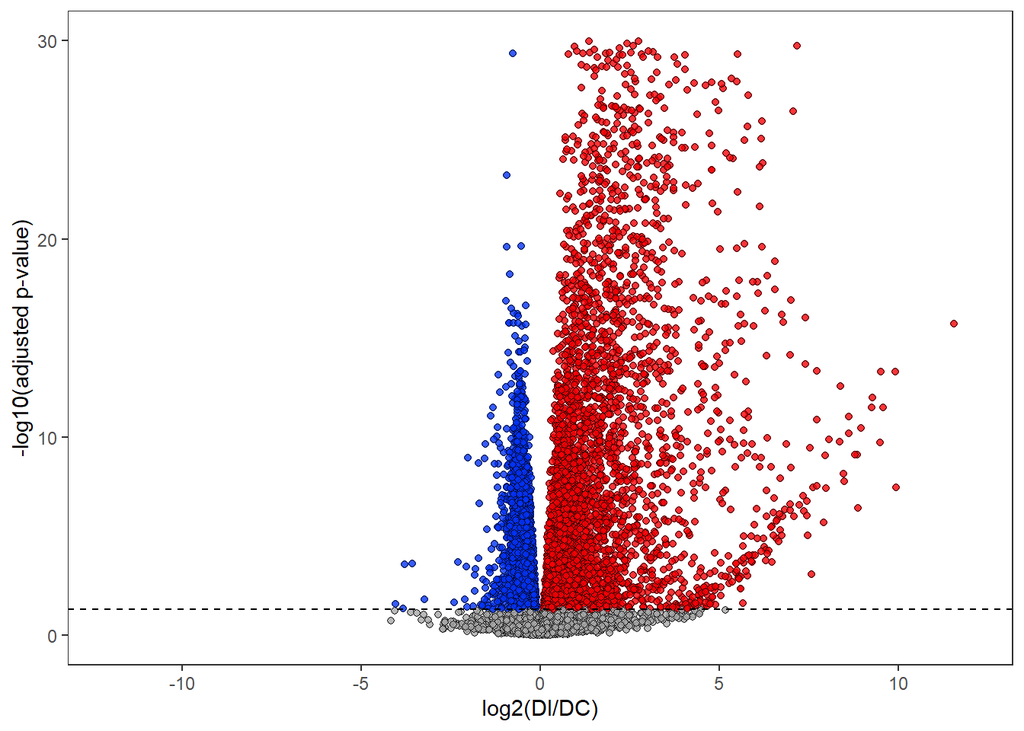

```r
Diff_set %>%
  ggplot(aes(DI_DC_log2FC, -log10(DI_DC_padj), fill = DI_DC_Status,
             label = Labels)) +
  geom_point(shape = 21, color = 'black', alpha = 0.8) +
  geom_hline(yintercept = -log10(FDR), linetype = 2) +
  xlab('log2(DI/DC)') +
  ylab('-log10(adjusted p-value)') +
    scale_y_continuous(limits = c(0, 30)) +
  scale_x_continuous(limits = c(-12, 12)) +
  scale_fill_manual(values = c(rgb(4, 51, 255, maxColorValue = 255),
                               rgb(251, 1, 6, maxColorValue = 255),
                               '#a9a9a9')) +
  theme_bw() +
  theme(legend.position = 'none',
        panel.grid = element_blank())
```

```r
ggsave('230619_ElAli_Volcano_DIvsDC_unlabeled.pdf',
       width = 4, height = 4, units = 'in')
```

# Heatmap

We need to get a matrix of TPM values for the selected genes for all samples, after which we will map the relative expression for each sample. Note that H2-Q5 is not detected in the dataset even though it was in the provided list. Further note that just because a gene is highly expressed in one condition versus the other in this graph does not mean the difference is statistically significant; refer to the table for this information.

```r
Heat_genes <- c('H2-Q1', 'H2-Q10', 'H2-Q2', 'H2-Q4', 'H2-Q8', 'H2-T-ps',
                'H2-T10', 'H2-T24', 'H2-DMb2', 'Pdzk1ip1', 'Spib', 'Pax5',
                'Ms4a1', 'Fcmr', 'Cd19', 'Cd79a', 'Cd79b', 'Glp2r',
                'Slc5a5', 'Mef2b', 'Fpr2', 'Fam89a', 'Shox2', 'Glp1r', 'Nrk',
                'Tbx15', 'Asgr1')

Heat_set <- Diff_set %>%
  filter(Gene %in% Heat_genes) %>%
  mutate(Gene = factor(Gene, levels = Heat_genes)) %>%
  arrange(Gene)

Heat_mat <- as.matrix(Heat_set[, c(12:14, 9:11, 18:20, 15:17)])
rownames(Heat_mat) <- Heat_set$Gene
Annotations <- data.frame(Condition = factor(c(rep('WC', 3),
                                               rep('WI', 3),
                                               rep('DC', 3),
                                               rep('DI', 3))))
rownames(Annotations) <- colnames(Heat_mat)
newnames <- lapply(rownames(Heat_mat),
                   function(x) bquote(italic(.(x))))
pheatmap(Heat_mat,
         scale = 'row',
         cluster_rows = FALSE,
         cluster_cols = FALSE,
         annotation_col = Annotations,
         annotation_names_col = FALSE,
         show_colnames = FALSE,
         labels_row = as.expression(newnames),
         filename = '230619_ElAli_Heat_relative.pdf',
         width = 4,
         height = 6)

Heat_genes <- c('Btk', 'Cd79a', 'Cd79b', 'Ccr6', 'Clcf1', 'Gpr183',
                'Jak3', 'Ikzf3', 'Malt1', 'Pax5', 'Tcirg1', 'H2-D1',
                'H2-DMb2', 'H2-Q1', 'H2-Q10', 'H2-Q4', 'H2-T10', 'H2-T24',
                'H2-T3')

Heat_set <- Diff_set %>%
  filter(Gene %in% Heat_genes) %>%
  mutate(Gene = factor(Gene, levels = Heat_genes)) %>%
  arrange(Gene)

Heat_mat <- as.matrix(Heat_set[, c(12:14, 9:11, 18:20, 15:17)])
rownames(Heat_mat) <- Heat_set$Gene
Annotations <- data.frame(Condition = factor(c(rep('WC', 3),
                                               rep('WI', 3),
                                               rep('DC', 3),
                                               rep('DI', 3))))
rownames(Annotations) <- colnames(Heat_mat)
newnames <- lapply(rownames(Heat_mat),
                   function(x) bquote(italic(.(x))))
pheatmap(Heat_mat,
         scale = 'row',
         cluster_rows = FALSE,
         cluster_cols = FALSE,
         annotation_col = Annotations,
         annotation_names_col = FALSE,
         show_colnames = FALSE,
         labels_row = as.expression(newnames),
         filename = '230621_ElAli_Heat_relative_Bcell_MHCII.pdf',
         width = 4,
         height = 6)

Heat_genes <- c('Glp1r', 'Trpc3', 'Trpc4', 'Chrna3', 'Slc5a5', 'Nalcn', 'Ank1',
                'Pygm', 'Ube3a', 'Kctd7', 'Mfn1', 'Shank2', 'Grin3a', 'Adgrl3',
                'Tbc1d24', 'Auts2', 'Dynlt1a', 'Pou4f1', 'Prox1', 'Wnt2')

Heat_set <- Diff_set %>%
  filter(Gene %in% Heat_genes) %>%
  mutate(Gene = factor(Gene, levels = Heat_genes)) %>%
  arrange(Gene)

Heat_mat <- as.matrix(Heat_set[, c(12:14, 9:11, 18:20, 15:17)])
rownames(Heat_mat) <- Heat_set$Gene
Annotations <- data.frame(Condition = factor(c(rep('WC', 3),
                                               rep('WI', 3),
                                               rep('DC', 3),
                                               rep('DI', 3))))
rownames(Annotations) <- colnames(Heat_mat)
newnames <- lapply(rownames(Heat_mat),
                   function(x) bquote(italic(.(x))))
pheatmap(Heat_mat,
         scale = 'row',
         cluster_rows = FALSE,
         cluster_cols = FALSE,
         annotation_col = Annotations,
         annotation_names_col = FALSE,
         show_colnames = FALSE,
         labels_row = as.expression(newnames),
         filename = '230621_ElAli_Heat_relative_ion_synapse.pdf',
         width = 4,
         height = 6)
```

# Venn diagrams

Using WC as a control condition, two Venn diagrams are to be made: upregulated genes in each condition versus WC, and the same for downregulated genes.

```r
Up_WI <- Diff_set %>%
  filter(WI_WC_Status == 'WI') %>%
  pull(Gene)
Up_DC <- Diff_set %>%
  filter(DC_WC_Status == 'DC') %>%
  pull(Gene)
Up_DI <- Diff_set %>%
  filter(DI_WC_Status == 'DI') %>%
  pull(Gene)
pdf('230307_ElAli_Venn_Up.pdf', 5, 4.5)
draw.triple.venn(length(Up_WI),
                 length(Up_DC),
                 length(Up_DI),
                 length(which(Up_WI %in% Up_DC)),
                 length(which(Up_DC %in% Up_DI)),
                 length(which(Up_WI %in% Up_DI)),
                 length(which(Up_WI %in% Up_DC & Up_WI %in% Up_DI)),
                 col = c(rgb(251, 1, 6, maxColorValue = 255),
                         rgb(4, 51, 255, maxColorValue = 255),
                         'brown'),
                 fill = c(alpha(rgb(251, 1, 6, maxColorValue = 255), 0.5),
                          alpha(rgb(4, 51, 255, maxColorValue = 255), 0.5),
                          alpha('brown', 0.5)),
                 category = c('Up WI', 'Up DC', 'Up DI'),
                 cex = 1.3,
                 cat.cex = 1.3,
                 fontfamily = 'sans',
                 cat.fontfamily = 'sans',
                 rotation.degree = 180,
                 cat.default.pos = 'outer')
```

[output not shown]

```r
dev.off()
```

```r
Dn_WI <- Diff_set %>%
  filter(WI_WC_Status == 'WC') %>%
  pull(Gene)
Dn_DC <- Diff_set %>%
  filter(DC_WC_Status == 'WC') %>%
  pull(Gene)
Dn_DI <- Diff_set %>%
  filter(DI_WC_Status == 'WC') %>%
  pull(Gene)
pdf('230619_ElAli_Venn_Dn.pdf', 5, 4.5)
draw.triple.venn(length(Dn_WI),
                 length(Dn_DC),
                 length(Dn_DI),
                 length(which(Dn_WI %in% Dn_DC)),
                 length(which(Dn_DC %in% Dn_DI)),
                 length(which(Dn_WI %in% Dn_DI)),
                 length(which(Dn_WI %in% Dn_DC & Dn_WI %in% Dn_DI)),
                 col = c(rgb(251, 1, 6, maxColorValue = 255),
                         rgb(4, 51, 255, maxColorValue = 255),
                         'brown'),
                 fill = c(alpha(rgb(251, 1, 6, maxColorValue = 255), 0.5),
                          alpha(rgb(4, 51, 255, maxColorValue = 255), 0.5),
                          alpha('brown', 0.5)),
                 category = c('Dn WI', 'Dn DC', 'Dn DI'),
                 cex = 1.3,
                 cat.cex = 1.3,
                 fontfamily = 'sans',
                 cat.fontfamily = 'sans',
                 cat.default.pos = 'outer')
```

[output not shown]

```r
dev.off()
```

# Subsets for GO

Subsets are taken for GO analysis. Those analyses will be done using Metascape.

```r
Diff_set %>%
  filter(WI_WC_Status == 'WI') %>%
  write_tsv('230619_ElAli_WIvsWC_WI.txt')
Diff_set %>%
  filter(WI_WC_Status == 'WC') %>%
  write_tsv('230619_ElAli_WIvsWC_WC.txt')
Diff_set %>%
  filter(DC_WC_Status == 'DC') %>%
  write_tsv('230619_ElAli_DCvsWC_DC.txt')
Diff_set %>%
  filter(DC_WC_Status == 'WC') %>%
  write_tsv('230619_ElAli_DCvsWC_WC.txt')
Diff_set %>%
  filter(DI_WC_Status == 'DI') %>%
  write_tsv('230619_ElAli_DIvsWC_DI.txt')
Diff_set %>%
  filter(DI_WC_Status == 'WC') %>%
  write_tsv('230619_ElAli_DIvsWC_WC.txt')
Diff_set %>%
  filter(DI_DC_Status == 'DI') %>%
  write_tsv('230619_ElAli_DIvsDC_DI.txt')
Diff_set %>%
  filter(DI_DC_Status == 'DC') %>%
  write_tsv('230619_ElAli_DIvsDC_DC.txt')
Diff_set %>%
  filter(DI_WI_Status == 'DI') %>%
  write_tsv('230619_ElAli_DIvsWI_DI.txt')
Diff_set %>%
  filter(DI_WI_Status == 'WI') %>%
  write_tsv('230619_ElAli_DIvsWI_WI.txt')
Diff_set %>%
  write_tsv('230619_ElAli_TPM_Full.txt')
```